# Causal models for qualitative and mixed methods inference

Process tracing

Macartan Humphreys and Alan Jacobs

# 1 Process Tracing

## 1.2 Crucial to keep in mind

- This tells us nothing about the *direction* of effects
- Inequality might boost or depress mobilization
- Mobilization might encourage or delay democratization (maybe it just leads to more repression)

## 1.3 How we’re conceiving of process tracing

- We are focusing on a case
- We start knowing *something* about the case
  - Perhaps the outcome
  - Perhaps the value of a causal condition or two
- What we don’t know is whether any of those conditions *caused* the outcome
- So we collect *more* information about the case to help figure that out

## 1.4 Formulating a case-level question: Malawi (1994)

- Suppose we observe democratization as the outcome in Malawi: $D=1$
- We also observe high inequality in Malawi: $I=1$
- We want to know: did $I=1$ cause $D=1$ in Malawi?

## 1.5 A simple process-tracing strategy

- We start out knowing $I=1$ and $D=1$
- We ask: did $I=1$ cause $D=1$?
- Let’s process trace: observe $M$ in Malawi
  - Was there mass mobilization in Malawi?

## 1.6 Collect the process tracing evidence ($M$)

- Suppose we go to the field and we learn that mass mobilization DID occur in Malawi
  - So $M=1$
- What can we conclude?
- NOTHING YET!

## 1.7 Why the DAG is not enough

- We knew $I=1$, $D=1$
- We then saw $M=1$
- But which is more consistent with $I=1$ causing $D=1$?
  - Mobilization occurring? or
  - Mobilization not occurring?

## 1.8 Why the DAG is not enough

- Suppose I believe that high inequality usually **prevents** mass mobilization
  - Poverty makes it harder to mobilize
- Suppose I also believe that mobilization usually **prevents** democratization
  - Instills fear in autocrats and provokes repression
- Which value of $M$ would be most consistent with $I=1$ causing $D=1$?
  - $M=0$

## 1.9 Why the DAG is not enough

- Suppose I believe that high inequality usually **causes** mass mobilization
  - Inequality creates grievances for protest
- Suppose I also believe that mobilization usually **causes** democratization
  - Instills fear in autocrats and provokes concessions
- Which value of $M$ would be most consistent with $I=1$ causing $D=1$?
  - $M=1$

## 1.10 Why the DAG is not enough

- If I believe inequality usually causes democratization by preventing mobilization, which itself hinders democratization…
  - then observing $M=0$ constitutes evidence that $I=1$ caused $D=1$
- If I believe inequality usually causes democratization by causing mobilization, which itself causes democratization…
  - then observing $M=1$ constitutes evidence that $I=1$ caused $D=1$

## 1.11 Process tracing is always theory dependent

- The evidence in process tracing never speaks for itself
- Our inferences from PT evidence always depend on theory
  - On our beliefs about how the world works
- Most process tracing is either silent about these beliefs or expresses them informally
- We can formalize these beliefs
  - Maximize explicitness and analytic transparency

## 1.12 An important implication of Bayesian reasoning

An example:

- The Lord of the Manor has been shot. Did the butler do it?
- Two theories of how he might have done so
  - Theory 1: He might have shot the Lord himself
    - We start out thinking this is a *likely* mechanism
  - Theory 2: He might have hired an assassin
    - We start out thinking this is an *unlikely* mechanism
- We find a piece of evidence
  - The bullet is from a Beretta 92FS
  - Commonly used by professional killers – rarely used by general population
- This strengthens belief in Theory 2, weakens belief in Theory 1 – *if the butler did it*
- But overall this evidence makes us *less* confident the butler did it at all!
  - Because it supports a very *unlikely* theory of how he’d have done it and undermines a likely theory

## 1.13 An important implication of Bayesian reasoning

- Often there are multiple ways in which some statement could be true
  - E.g., there are multiple mechanisms through which $I$ could have a positive effect on $D$
  - Linked positive effects, or
  - Linked negative effects
- Those different ways are not equally likely, though
  - Maybe linked positive effects are much more likely than linked negative effects as ways of making “I has a positive effect on D” a true statement
- Evidence that we collect will tell us which “ways” are more likely operating in a case

## 1.14 An important implication of Bayesian reasoning

- When the evidence shifts our beliefs toward thinking that a *likely* theory/mechanism for some cause is operating, that makes it more likely that the cause is operating
- When evidence shifts our beliefs away from thinking that a *likely* theory/mechanism for some cause is operating and toward thinking an *unlikely* theory/pathway is operating, that makes it **less likely** that the cause is operating
- **We “lose” more by undermining the likely mechanism than we gain by boosting the unlikely mechanism**
- So it matters how likely we think the different possible mechanisms are
  - Will affect how we interpret the evidence
- These are “priors”

## 1.15 Two theories of how $I=1$ could cause $D=1$

- Chain of positive effects
  - Inequality *boosts* mobilization
  - Mobilization *causes* democratization
- Chain of negative effects
  - Inequality *depresses* mobilization
  - Mobilization *prevents* democratization

## 1.16 Interpretation of PT evidence *depends* on theory

In particular: beliefs about which mechanism is most likely operating

If we have already seen $I=1, D=1$

- Linked positive effects requires us to then see: $M=1$
- Linked negative effects requires us to then see: $M=0$
- So which $M$ value is more consistent with a positive $I \rightarrow D$ effect depends on **which of these is more common in the world**:
  - Linked positive effects?
  - Linked negative effects?
- We need to draw on our theoretical beliefs
  - about the **distribution** of causal effects in the relevant population

## 1.17 Combining beliefs across the DAG

- Suppose we believe that:
  - $I$ has a positive effect on $M$ 30% of the time (= in 30% of cases in the population)
  - $I$ has a negative effect on $M$ 10% of the time
- Suppose we believe that:
  - $M$ has a positive effect on $D$ 60% of the time
  - $M$ has a negative effect on $D$ 10% of the time
- Then the probability of linked positive effects is simply…
  - $0.3 \times 0.6 = 0.18$
- Probability of linked negative effects is simply…
  - $0.1 \times 0.1 = 0.01$
- So we believe linked positive effects are a MUCH more common way of generating a positive $I \rightarrow D$ effect than linked negative effects

## 1.18 From beliefs to the meaning of the evidence

- We believe linked positive effects are a MUCH more common way of generating a positive $I \rightarrow D$ effect than linked negative effects
- Given $I=1$ and $D=1$, there can only be linked positive effects IF mobilization occurs ($M=1$)
- So if we observe $M=1$, we will think it’s more likely that high inequality DID cause democratization
  - Because $M=1$ is consistent with the MORE likely way this effect could have happened
- If we observe $M=0$, we think it’s less likely that high inequality caused democratization
  - Because $M=0$ is consistent only with the LESS likely way this effect could have happened

## 1.20 Process tracing in Malawi

To recap:

- We want to know if $I=1$ caused $D=1$ in Malawi
- Given our DAG, there are two ways to generate a positive effects of $I$ on $D$
  - Two ways that high inequality could have caused democratization in Malawi
  - Linked positive effects or linked negative effects
- When we see $M=1$ in Malawi, what we should conclude about $I$’s effect on $D$ depends on how we think the world works
  - What kinds of effects do we think are most common at each step
- This defines what **ways** of generating a positive $I \rightarrow D$ are most/least common
- Which tells us which value of $M$ is most consistent with such an effect

## 1.21 Process tracing in Malawi

- Prior beliefs we use in the book (roughly):
  - $I$ has positive effect on $M$ 50% of the time
  - $I$ never has a negative effect on $M$
  - $M$ has positive effect on $D$ 50% of the time
  - $M$ never has a negative effect on $D$
- We process trace and observe that mobilization occurred: $M=1$
- Given our priors, this observation **increases** our confidence that $I=1$ caused $D=1$

## 1.22 Where do these prior beliefs come from?

- Literature
  - We draw on leading works on inequality and democratization (Boix, Acemoglu and Robinson, Ansell and Samuels)
- Deductive theorization
  - E.g., a formal model (see Chapter 6.3)
- Crowd-sourcing
  - Survey experts
- Cannot read directly off population-level descriptives
  - E.g., the number of $I=1, M=1$ cases tells us nothing about how often inequality *causes* mobilization

## 1.23 Process tracing for several cases

## 1.24 Process tracing for several cases

- With different possible clues we could observe

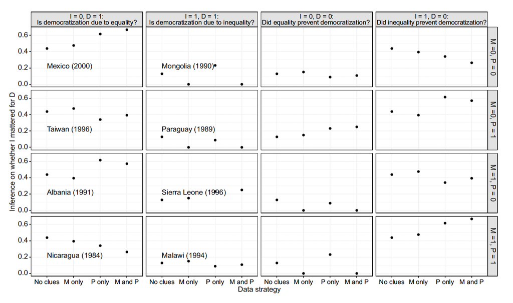

## 1.25 Process tracing to answer a pathway question

- Similar idea for answering a pathway question
- Observing $M$ can help us figure out *how* $I$ caused $D$
- Once we provide population-level beliefs about causal effects

## 1.26 Other pieces of evidence

- $P$ can also be informative about $I$’s effect on $D$
- Will depend on our population-level beliefs about $P$’s effects on $D$ and interactions with $M$

## 1.27 Process tracing with causal models

- The DAG tells us what we can possibly observe
- We will have seen some nodes before we process trace (e.g., outcome, possible causes)
- We can then observe any other node on the DAG
- What we learn about the **case** from observing a node depends on our beliefs about how things work in the **population**
  - What kinds of effects are most and least common?
- How strongly our beliefs shift depends on how different those probabilities are
  - How *much* more common are linked positive effects than linked negative effects, for instance?
- In book, some rules about when nodes are **potentially** informative

## 1.28 Process tracing with causal models

Key advantages of using a causal model:

- Makes clear how process tracing is always theory-dependent
- Provides a way of systematically integrating background knowledge (theory) into inference
- Makes highly explicit/transparent how we get from evidence to conclusions
- Enhances evaluability of findings
  - If I have different background beliefs from you, I can work out how my conclusions from same evidence would be different

# 2 Procedure for process tracing

## 2.1 By hand: Procedure

1. Make a table with rows for all causal types (there may be many if you are doing by hand!!)
2. Add a column to indicate your priors over these causal type
3. Add a column to say if the query is satisfied by the causal types
4. Calculate the conditional distributions given the types

## 2.2 By hand: Example

Our DAG is:

$X \rightarrow M \rightarrow Y$

And we believe:

- $X=1$ for half the cases, randomly
- $X$ has a positive effect on $M$ for half the cases (“causes”), in the other half $M=0$ regardless of $X$
- $M$ has a positive effect on $Y$ for half the cases, in the other half $Y=0$ regardless of $M$

## 2.3 By hand: Example

What are the types? How likely is each one? Which ones satisfy the following query: $Y = 0$ *because* $X=0$?:

| Type | X | M | Y | prob | Query? |
| --- | --- | --- | --- | --- | --- |
| X = 0, X causes M, M causes Y | 0 | 0 | 0 | 1/8 | Yes |
| X = 0, X causes M, M does not cause Y | 0 | 0 | 0 | 1/8 | No |
| X = 0, X does not cause M, M causes Y | 0 | 0 | 0 | 1/8 | No |
| X = 0, X does not cause M, M does not cause Y | 0 | 0 | 0 | 1/8 | No |
| X = 1, X causes M, M causes Y | 1 | 1 | 1 | 1/8 | No |
| X = 1, X causes M, M does not cause Y | 1 | 1 | 0 | 1/8 | No |
| X = 1, X does not cause M, M causes Y | 1 | 0 | 0 | 1/8 | No |
| X = 1, X does not cause M, M does not cause Y | 1 | 0 | 0 | 1/8 | No |

## 2.4 With CausalQueries

```r
model <-
  make_model("X -> M -> Y") |>
  set_restrictions("M[X = 0] == 1") |>
  set_restrictions("Y[M = 0] == 1")

inspect(model, "causal_types")
```

```
causal_types (Causal Types)

Cartesian product of nodal types
           X  M  Y
X0.M00.Y00 0 00 00
X1.M00.Y00 1 00 00
X0.M01.Y00 0 01 00
X1.M01.Y00 1 01 00
X0.M00.Y01 0 00 01
X1.M00.Y01 1 00 01
X0.M01.Y01 0 01 01
X1.M01.Y01 1 01 01
```

## 2.5 With CausalQueries

```r
query_model(model, "Y[X=1]==1 :|: X==0 & Y == 0")
```

```
Causal queries generated by query_model (all at population level)

|label                         |using      | mean|
|:-----------------------------|:----------|----:|
|Y[X=1]==1 given X==0 & Y == 0 |parameters | 0.25|
```

# 3 References

### 3.0.1 References